# Setup and Run Model

```
## [1] "Running Time"
```

```
##    user  system elapsed
##    0.07    0.11  584.16
```

```
## [1] "Number of Scenarios"
```

```
## [1] 12
```

# Tests for Model Version 49

Notes on the organization of the tests:

- If a test involves a child in any way, it goes in the child section.
- If a test involves only one transition, then it goes into that transition's section. This includes test that only test the effect of one parameter. If that parameter is specifically associated with only one transition, then the test goes there.
- Any other test goes under the heading of the scenario it uses.
- If a test does not fit any of these categories, dump it in the General section.

## Mother - Transitions

### Transition 1 - Death of Uninfected Mothers

#### No deaths from healthy in OnlyInfectedMortality

Scenario(s): OnlyInfectedMortality

No mothers should die from the Healthy state in the OnlyInfectedMortality Scenario

To Summary Table

```
##                                  metrics     ..1
## 1                 Healthy Mortality Rate       0
## 2           Healthy mother years at risk 3029205
## 3                Infected Mortality Rate      NA
## 4          Infected mother years at risk 1022394
## 5                   Mother years at risk 4051599
## 6                       Number of deaths  100000
## 7    Number of deaths from HEALTHY state       0
## 8   Number of deaths from INFECTED state   86803
## 9    Number of deaths from STOPPED state       0
## 10   Number of deaths from TREATED state       0
## 11                Overall Mortality Rate      NA
## 12                Treated Mortality Rate      NA
## 13          Treated mother years at risk       0
## 14       Treatment Ceased Mortality Rate      NA
## 15 Treatment Ceased mother years at risk       0
```

**Result: TRUE**

#### Healthy Mortality Match Inputs

Scenario(s): NoHIV

When the kaplan meier curves of the healthy mortalities are compared to the input ASSA mortalities, then they must be similar.

Note that the input parameters are not perfectly translated into a curve. This can be optimized in the future, but I believe it is good enough for a quick check.

To Summary Table

```
## Error: nrow(healthy_mort) >= 90 is not TRUE
```

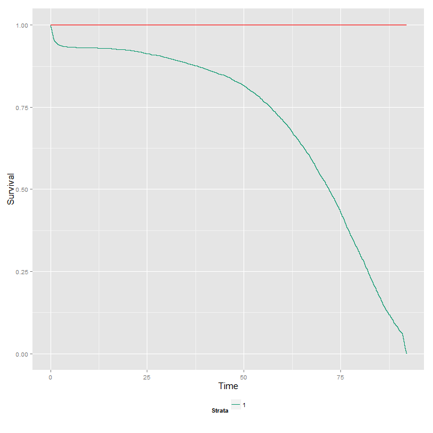

**Result: Manual**

### Transition 2 - HIV Infection

#### Percentage ever infected zero in NoHIV

Scenario(s): NoHIV

The number of mothers ever infected in the NoHIV case should be 0

To Summary Table

```
## $total_infections
## [1] 0
```

**Result: TRUE**

### Transition 3 - Death of Infected Mothers

#### No deaths from Infected in OnlyTreatedMortality

Scenario(s): OnlyTreatedMortality

No mothers should die from the Infected state in the OnlyTreatedMortality Scenario

To Summary Table

```
##                                  metrics     ..1
## 1                 Healthy Mortality Rate       0
## 2           Healthy mother years at risk 2340013
## 3                Infected Mortality Rate      NA
## 4          Infected mother years at risk 2823484
## 5                   Mother years at risk 6531887
## 6                       Number of deaths  100000
## 7    Number of deaths from HEALTHY state       0
## 8   Number of deaths from INFECTED state       0
## 9    Number of deaths from STOPPED state       0
## 10   Number of deaths from TREATED state   79094
## 11                Overall Mortality Rate      NA
## 12                Treated Mortality Rate      NA
## 13          Treated mother years at risk 1368391
## 14       Treatment Ceased Mortality Rate      NA
## 15 Treatment Ceased mother years at risk       0
```

**Result: TRUE**

#### Infected Mortality Match van der paal

Scenario(s): OnlyInfectedMortality

When the kaplan meier curves of the infected mortalities are fitted with Weibull curves, the parameters must be similar to those obtained from the van der paal article

To Summary Table

```
## Number of deaths by Van Der Paal Age category:
```

```
##
##    1    2    3    4
## 4000  318   58   15
```

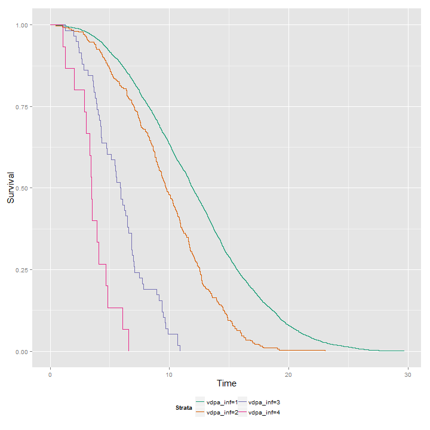

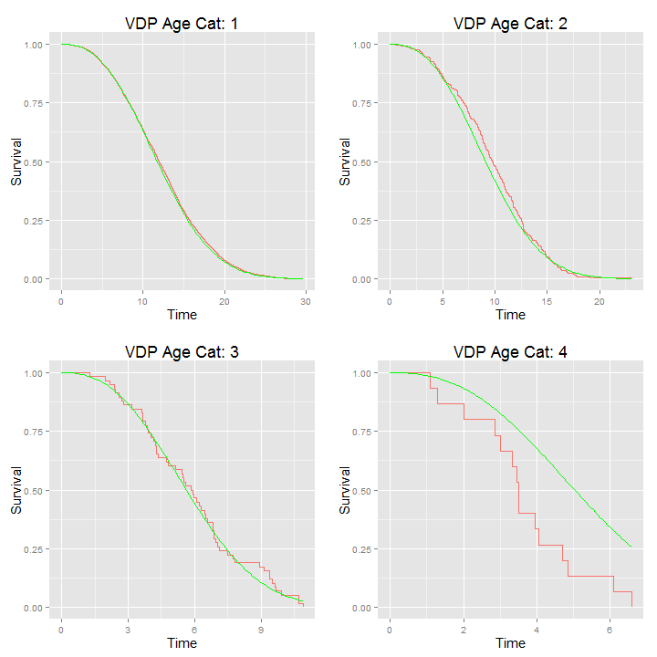

**Result: Manual**

### Transition 4 - Development of Symptoms of HIV Infected Mothers

#### Symptom Rates Match van der paal

Scenario(s): AllInfectedNoMortality

When the kaplan meier curves of the symptom rates are fitted with Weibull curves, the parameters must be similar to those obtained from the van der paal article

To Summary Table

```
## Number of deaths by Van Der Paal Age category:
```

```
##
##    1    2    3    4
## 4000  318   58   17
```

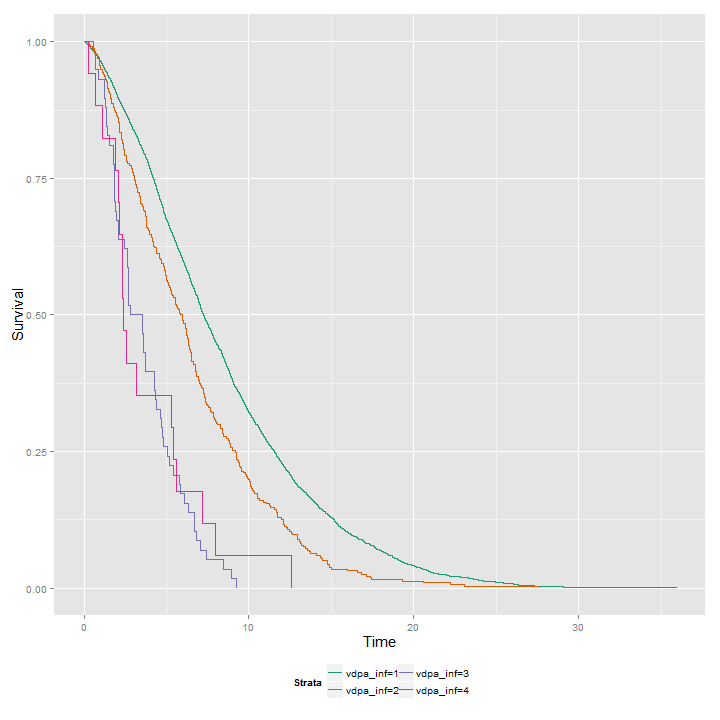

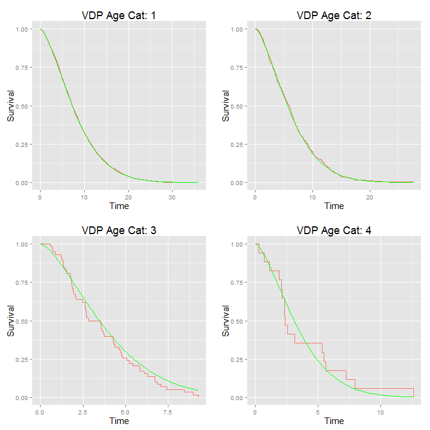

**Result: Manual**

### Transition 5 - Diagnosis of Asymptomatic Mothers

#### Asymptomatic Exponential Diagnosis Rates matches inputs

Scenario(s): AllInfectedNoSympNoMortExpDiag

When the kaplan meier curves of the asymptomatic diagnosis rates are compared to the input values, they should look similar. This is only for the case where the transition is based on the exponential distribution

To Summary Table

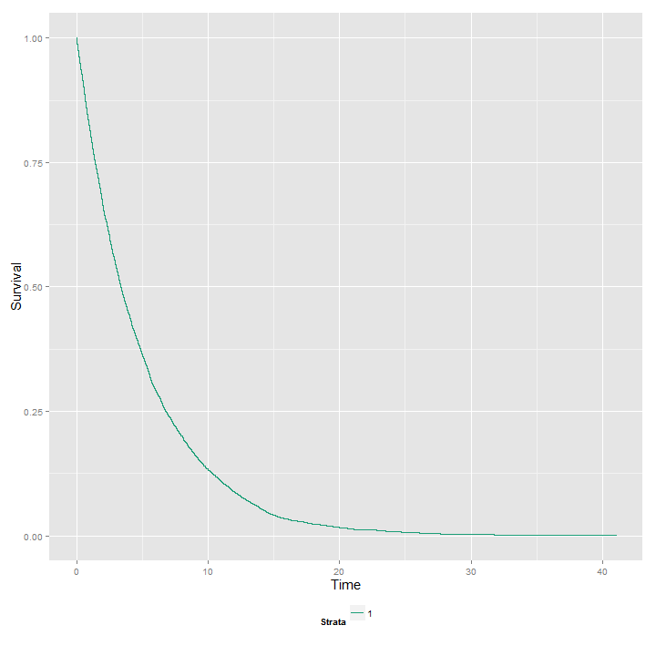

```
## Mean time till diagnosis from onset of symptoms: 4.91462966324458.
```

**Result: Manual**

#### Asymptomatic Percentage Diagnosis Rates matches inputs

Scenario(s): Base

The percentage of mothers who become diagnosed while asymptomatic must match the input rate.

This test is only for the case where the transition is based on a percentage and not on a exponential curve.

To Summary Table

```
## $`output infected mothers`
## [1] 39992
##
## $`output diagnosed mothers`
## [1] 16114
##
## $`output percentage`
## [1] 0.4029
##
## $`input percentage`
## [1] 0.4
##
## $`input / output ratio`
## [1] 0.9927
```

**Result: TRUE**

### Transition 6 - Diagnosis of Symptomatic Mothers